# Simulated dynamic spectra for Hilbert-Schmidt decomposition experiments

Created 2024-05-10 by Tom Loredo

This notebook demonstrates construction of simulated spectra that **qualitatively** resemble stellar spectra with a continuum and absorption lines that vary due to stellar activity.

A time-varying spectrum is built via a time-dependent mixture of three components, each separately pre-computed by solving the radiative transfer equation in plane-parallel geometry, assuming local thermodynamic equilibrium (LTE), and using the model photosphere and lower chromosphere atmosphere profile "C" from Fontenla+ (1993; FAL93). Model C was designed to resemble an "average intensity area" of the quiet Sun. For absorption lines, the spectra used here include two highly saturated lines patterned after the Ca H and K Fraunhofer lines, and a set of shallower lines at arbitrary locations, and assigned atomic masses corresponding to elements producing other Fraunhofer lines. The line interaction profiles are Voigt profiles, and the central optical depths are set arbitrarily, and are constant with depth (i.e., ion densities are not used).

The three component spectra are:

- A *quiet* (Q) component, using the FAL93 model C atmosphere.
- A cooler *spot* (S) component, using model C with the temperature scaled down by the ratio of a typical sunspot temperature to the quiet Sun photosphere temperature, (3750 K / 5772 K).
- A slightly hotter *faculae* (F) component, using model C with the temperature increased everywhere by 300 K (corresponding to the typical temperature increase for facular walls or the region outside the central "Wilson depression").

For each component, two spectra are provided, a *continuum* spectrum (with no absorption lines), and a *full* spectrum (adding in absorption lines). Since EPRV spectrometers do not have very good absolute calibration, astronomers typically analyze *relative* spectra (i.e., the observed full spectrum divided by a continuum estimate found by smoothing the observed spectrum), or sometimes *residual* spectra (i.e., full minus continuum divided by continuum). Here we will look at full, continuum, and relative dynamic spectra.

The pre-calculated components are loaded in this notebook, and classes provided here mix them in various ways as a function of time to produce dynamic spectra.

A set of three components is stored in a *SpectraSet* object. Two sets are available:

- A *narrow* set for which the Doppler line broadening arises from the thermal structure of the atmosphere.
- A *wide* set for which the Doppler broadening includes an unrealistically large turbulent velocity component ($v_t ~ 150$ km/s for H, and scaled inverselty by `sqrt(atomic mass)` for other elements). This set makes the features and their evolution more visually prominent, which may aid in elucidating how spectrum decomposition methods perform.

This notebook was developed using a Conda/Mamba environment built as follows (`conda` may be used in place of `mamba`):

```
$ mamba create --name eprv10 -c conda-forge -c defaults python=3.10 ipython jupyter jupyterlab jupyterlab_widgets scipy matplotlib ipympl \
  h5py beautifulsoup4 html5lib bleach pandas sortedcontainers \
  pytz setuptools mpmath bottleneck jplephem asdf pyarrow colorcet hypothesis astropy pooch tqdm copier gsl
```

Activate it with `mamba activate eprv10`.

I use this environment for general exoplanet EPRV experimentation, and not all of the packages listed above are required for this notebook to run. Feel free to try it in an existing environment of your own.

First, some PyData imports:

```python
import numpy as np
from numpy import *

import matplotlib as mpl
import matplotlib.pyplot as plt
from matplotlib.pyplot import *

import colorcet as cc
```

The `dynspecmix` module includes various helpers used here:

```python
from dynspecmix import SpectraSet, SpecMixer
from dynspecmix import plot_full_cont, plot_rel
```

We'll use the `ipywidget` framework with `matplotlib`, to get zoomable plots so we can examine details in the plots. This relies on the `ipympl` package (included in the `eprv10` environment).

```python
%matplotlib widget
```

## Load and plot the quiet/spot/faculae components

Two HDF5 data files provided with this notebook contain the narrow and wide SpectraSets:

```python
narrow = SpectraSet('FAL-C-narrow.h5')
wide = SpectraSet('FAL-C-wide.h5')
```

```
Loaded HDF5 store FAL-C-narrow.h5:
  cont_f: <HDF5 dataset "cont_f": shape (37537,), type "<f8">
  cont_q: <HDF5 dataset "cont_q": shape (37537,), type "<f8">
  cont_s: <HDF5 dataset "cont_s": shape (37537,), type "<f8">
  full_f: <HDF5 dataset "full_f": shape (37537,), type "<f8">
  full_q: <HDF5 dataset "full_q": shape (37537,), type "<f8">
  full_s: <HDF5 dataset "full_s": shape (37537,), type "<f8">
  lambdas: <HDF5 dataset "lambdas": shape (37537,), type "<f8">
Loaded HDF5 store FAL-C-wide.h5:
  cont_f: <HDF5 dataset "cont_f": shape (37537,), type "<f8">
  cont_q: <HDF5 dataset "cont_q": shape (37537,), type "<f8">
  cont_s: <HDF5 dataset "cont_s": shape (37537,), type "<f8">
  full_f: <HDF5 dataset "full_f": shape (37537,), type "<f8">
  full_q: <HDF5 dataset "full_q": shape (37537,), type "<f8">
  full_s: <HDF5 dataset "full_s": shape (37537,), type "<f8">
  lambdas: <HDF5 dataset "lambdas": shape (37537,), type "<f8">
```

We'll pick one of these to use for the rest of the notebook; **switch between `narrow` and `wide` here** and re-run the notebook to examine the results for the different cases.

```python
sset = wide
ll, lu = sset.lambdas[0], sset.lambdas[-1]  # wavelength span (angstroms)
```

Plot the full and continuum spectra for each of the three components; the ordinate is specific intensity emerging normal to the stellar surface (energy/time/area/solid angle, per unit wavelength).

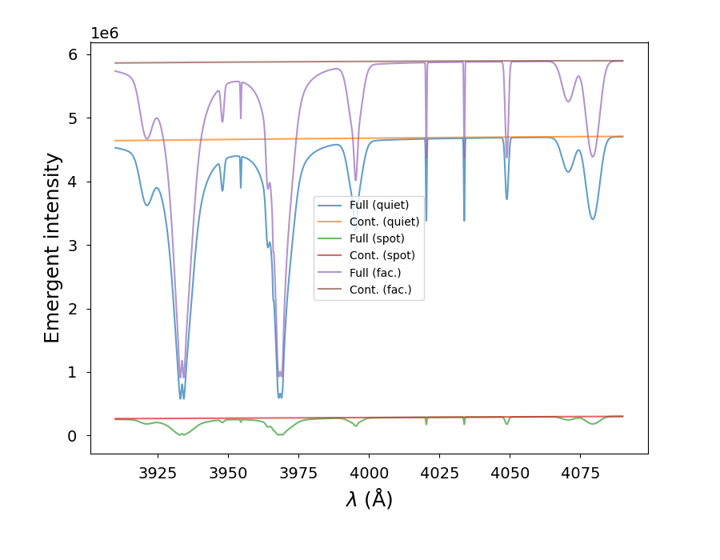

```python
plot_full_cont(sset)
```

Note that the colder sunspot spectrum is significantly less intense than the quiet or faculae spectra; this is why sunspots appear black, even though an object at 3750 K on Earth would appear "white hot."

Now plot the relative spectra:

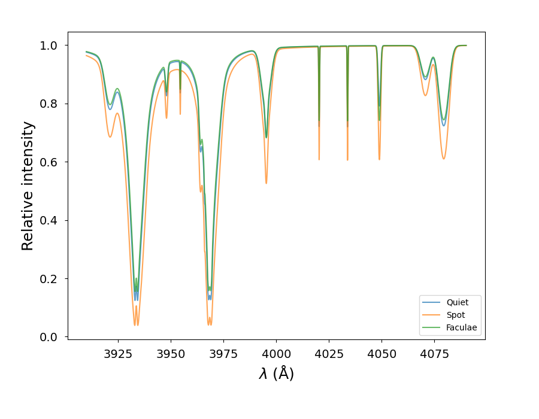

```python
plot_rel(sset)
```

# Classes for producing dynamic spectra

The `SpecMixer` class from the `dynspecmix` module is an abstract base class; we need to create a subclass of it to mix the quiet/spot/faculae components to generate a dynamic spectrum. The base class provides most of the machinery; the subclass just has to specify the time dependences ("modulators") for the spot and faculae mixing fractions.

Here is a mixer subclass that lets the spot and faculae components change linearly with time:

```python
class RampSpecMix(SpecMixer):
    """
    Mix spot and faculae spectra using linear ramps in time.
    """

    def __init__(self, sset, ab_spot, ab_fac):
        """
        Define a dynamic spectrum that linearly ramps contributions from the
        spot and faculae components proportional to (a + b*t), with
        the 2-tuples `ab_spot` and `ab_fac` providing the coefficients.

        Ensure that (a + b*t) is in [0,1] for each component, and that the
        sum never exceeds 1.
        """
        super().__init__(sset)
        self.a_s, self.b_s = ab_spot
        self.a_f, self.b_f = ab_fac

    def mod_spot(self, t):
        return self.a_s + self.b_s*t

    def mod_fac(self, t):
        return self.a_f + self.b_f*t
```

And here is one that is loosely inspired by more physical behavior, with the spot component evolving proportional to a half sinusoid (mimicking how a spot gradually appears and then disappears over half of a star's rotation), and a facular component evolving proportional to a related sinusoid that is always present, and that includes a 2nd component at twice the rotationaly frequency (half the period). This is meant to reflect that spots are always accompanied by faculae, but that faculae are also commonly present without spots. Also, faculae are limb *brightened* (in contrast to the limb *darkening* seen for the quiet photosphere); this is believed to be due to the faculae being magenetically-induced depressions in the photosphere, with walls that are hotter than the photosphere (we preferentially see the hotter walls as the faculae approach the limb). We won't try to mimic that behavior in detail here, but the 2nd harmonic is meant to add a bit of complexity reflecting such behavior.

```python
class SineSpecMix(SpecMixer):
    """
    Mix spot and faculae spectra using a half sinusoid for the spot
    and a sum of two sinusoids for the faculae.
    """

    w = 2*pi  # angular frequency for period = 1
    phi = 2*pi/4  # phase offset for spot modulation

    def __init__(self, sset, amp_s, amp_f1, amp_f2):
        """
        Define a dynamic spectrum that mixes in a spot component as a
        half sinusoid (in the middle of [0,1]), and a faculae component
        as a similar full sinusoid, and a sinusoid with twice the
        frequency.  The `amp` parameters are the amplitudes of the
        sinusoids (the faculae term gets offset by the sum of its amplitudes).

        Currently there is no check that the mixed spectral components are all
        always positive.
        """
        super().__init__(sset)
        self.amp_s = amp_s
        self.amp_f1, self.amp_f2 = amp_f1, amp_f2

    def mod_spot(self, t):
        mod = 0.
        if t > 0.25 and t < 0.75:
            mod += self.amp_s*sin(self.w*t - self.phi)
        return mod

    def mod_fac(self, t):
        mod = self.amp_f1 + self.amp_f2
        mod += self.amp_f1*sin(self.w*t - self.phi)
        mod += self.amp_f2*sin(2*self.w*t - self.phi)
        return mod
```

## Generate and plot dynamic spectra

We'll arbitrarily use the unit interval for the time range, and use 201 time points.

```python
tl, tu = 0., 1.  # lower, upper limits for time
nt = 201
tvals = linspace(tl, tu, nt)
```

Here we **pick one of the two mixing classes** to generate a dynamic spectrum. Change `True` to `False` (or vice versa) and re-run the cells below to change between the linear ramp and sinusoid behaviors.

```python
if False:
    # Spot ramping from 0 to 50%, faculae ramping down from 50% to 0:
    rsm = RampSpecMix(sset, (0., .5), (.5, -.5))
    full, cont = rsm.dynspec(tvals)
else:
    # Half-sinusoid spot and two-sinusoid faculae:
    ssm = SineSpecMix(sset, .3, .1, .05)
    full, cont = ssm.dynspec(tvals)
```

We now have full and continuum dynamic spectra available for analysis; the relative spectrum is just the ratio, `full/cont`.

Let's plot them as images in a 2-panel plot:

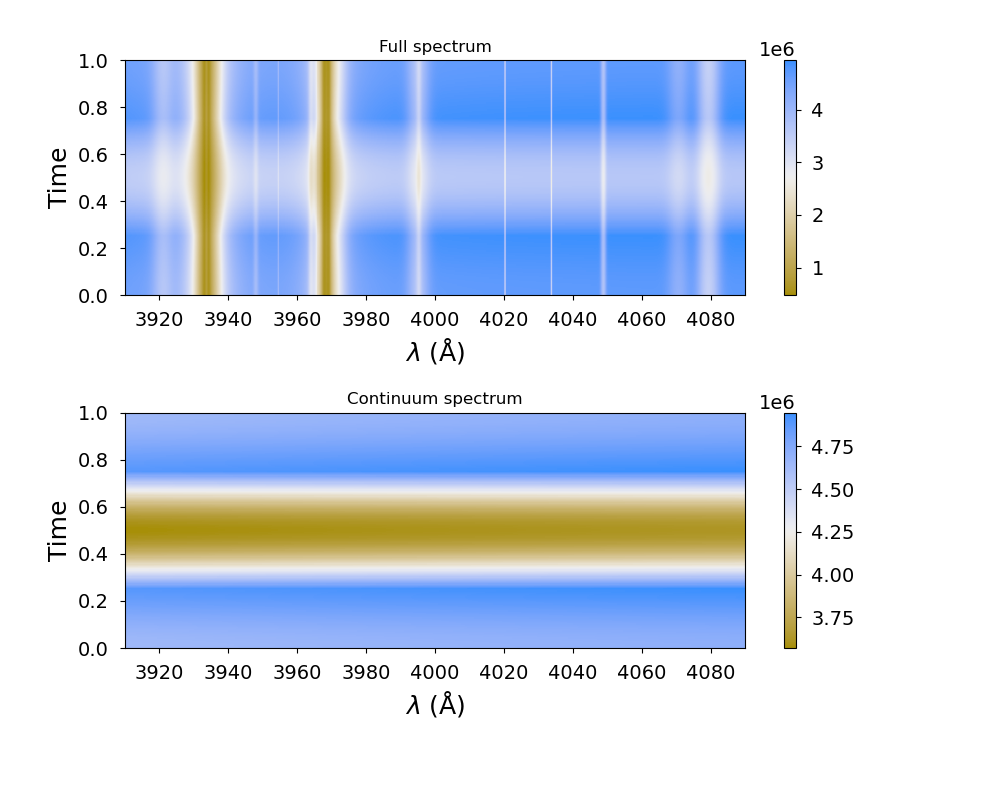

```python
    fig, pnl = subplots(2, 1, figsize=(10,8))
    subplots_adjust(hspace=.5)

    sca(pnl[0])
    title('Full spectrum')
    xlabel('$\\lambda$ (\u00c5)')
    ylabel('Time')
    # imshow(full)
    imshow(full, cmap=cc.cm.bwy_r, interpolation='nearest', aspect='auto',
           origin='lower', extent=(ll, lu, tl, tu))
    xlim(ll, lu)
    colorbar()

    sca(pnl[1])
    title('Continuum spectrum')
    xlabel('$\\lambda$ (\u00c5)')
    ylabel('Time')
    # imshow(full)
    imshow(cont, cmap=cc.cm.bwy_r, interpolation='nearest', aspect='auto',
           origin='lower', extent=(ll, lu, tl, tu))
    xlim(ll, lu)
    colorbar()
```

Display a selection of *relative* spectra at a few times (i.e., a few horizontal slices of the ratio of those two images):

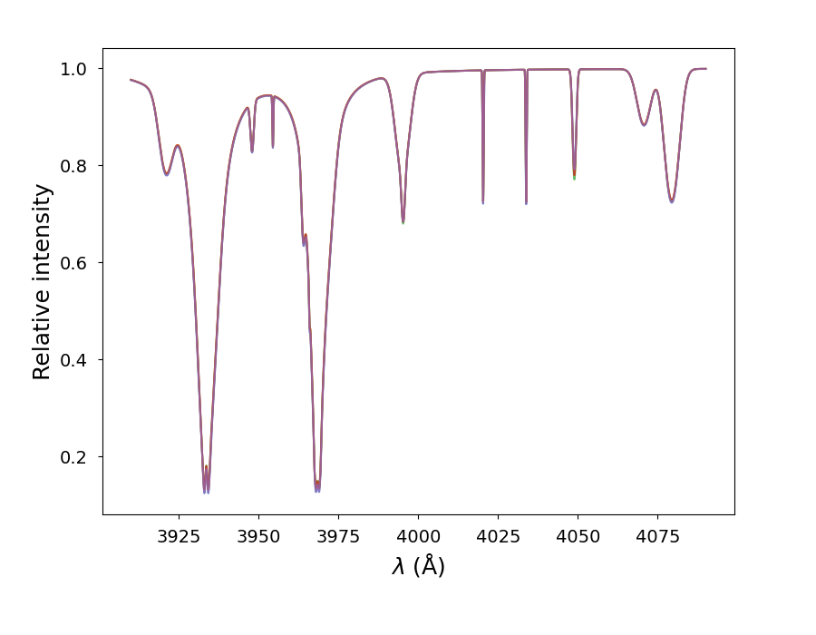

```python
rel = full/cont

fig, ax = subplots(figsize=(9,7))
xlabel('$\\lambda$ (\u00c5)')
ylabel('Relative intensity')

lambdas = sset.lambdas
plot(lambdas, rel[0], '-', alpha=.7)
plot(lambdas, rel[nt//4], '-', alpha=.7)
plot(lambdas, rel[nt//2], '-', alpha=.7)
plot(lambdas, rel[3*nt//4], '-', alpha=.7)
plot(lambdas, rel[-1], '-', alpha=.7)
```

There are 5 spectra there; they look quite similar. We can zoom in on the plot above using the widget tools to see the differences.

Alternatively, we can display the relative dynamic spectrum as an image—which we might guess will look like it is not varying much—but also as a *difference image*, i.e., as the difference bewteen the spectrum and its time average, which will make the variability much more apparent.

Here's the relative difference spectrum:

```python
avg = rel.sum(0) / nt
diff = rel - avg
l, u = diff.min(), diff.max()
diff = (diff - l)/(u - l)
```

Here are images of the relative spectrum and the difference spectrum:

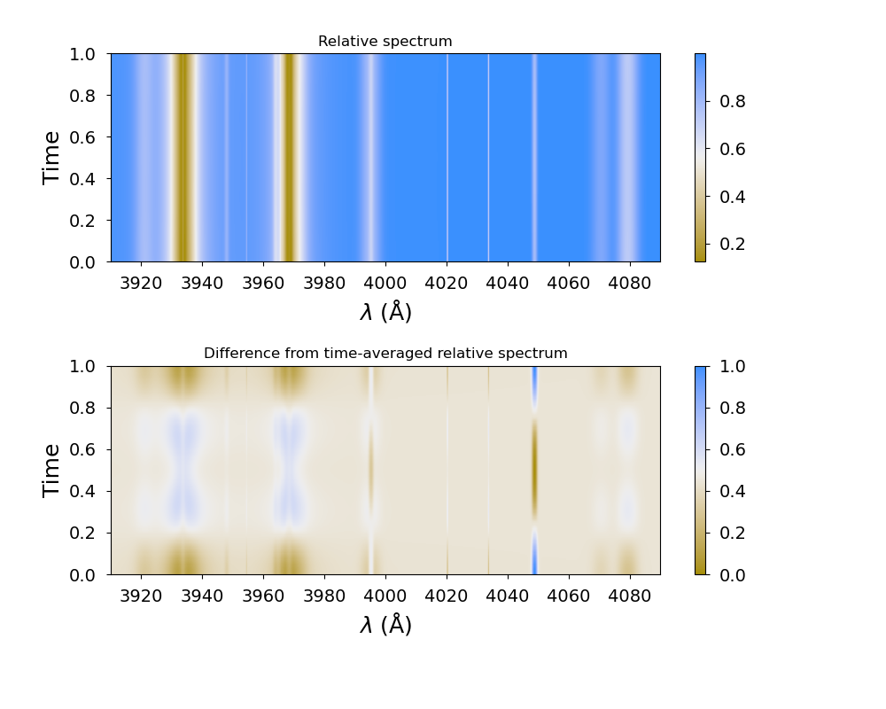

```python
    fig, pnl = subplots(2, 1, figsize=(10,8))
    subplots_adjust(hspace=.5)

    sca(pnl[0])
    title('Relative spectrum')
    xlabel('$\\lambda$ (\u00c5)')
    ylabel('Time')
    # imshow(full)
    imshow(rel, cmap=cc.cm.bwy_r, interpolation='nearest', aspect='auto',
           origin='lower', extent=(ll, lu, tl, tu))
    xlim(ll, lu)
    colorbar()

    sca(pnl[1])
    title('Difference from time-averaged relative spectrum')
    xlabel('$\\lambda$ (\u00c5)')
    ylabel('Time')
    # imshow(full)
    rel = full/cont
    imshow(diff, cmap=cc.cm.bwy_r, interpolation='nearest', aspect='auto',
           origin='lower', extent=(ll, lu, tl, tu))
    xlim(ll, lu)
    colorbar()
```

At this point analysis via HSD or PCA can proceed as we did earlier with SOAP2 simulated spectra. We could write out dynamic spectra here to read into another notebook, or add cells below for the analysis. There are various cases to consider exploring:

- Choose either the narrow or the wide SpectraSet inputs.
- Choose either the linear ramp or the sinusoid modulations (or create a new one).
- Analyze the difference spectrum (as I believe we did earlier), or the full spectrum (subtracting off its average).

Some thoughts/suggestions:

- Probably start with the wide inputs; it may be easier to visualize how the decompositions behave with the stronger features in these inputs.
- The relative difference spectrum is closest to what observed data are like, since observers typically produce relative spectra (and HSD and PCA require subtracting off the mean). But it's worth considering analysis of the full spectra direction (subtracting the mean as necessary). Since we are producing spectra via linear mixing, the full spectra probably can be exactly decomposed with three speclet/modulator pairs (they probably correspond to some kind of orthogonalization of the three input components and the three modulators). For the relative spectra, I suspect the division by the (time-dependent) continuum spectrum probably prevents a finite decomposition from being exact.